# Batch Code Run (Saved State)

## Smoothen Trajectories

```python
t2_smooth=trajectories_tp.groupby('particle').apply(median_smooth_trajectory)
```

```python
t2_smooth = t2_smooth.reset_index(drop=True)
```

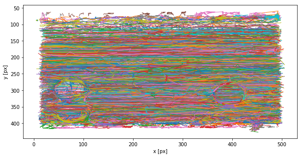

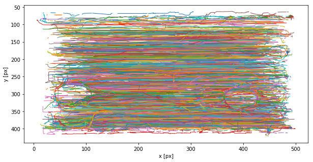

```python
tp.plot_traj(t2)#.groupby('particle').filter(lambda x: single_traj_angle(x) > 70 and tp.diagonal_size(x)>100))
tp.plot_traj(t2_smooth)#.groupby('particle').filter(lambda x: single_traj_angle(x) > 70 and tp.diagonal_size(x)>100))
```

## Plot of Angle vs/ Distance

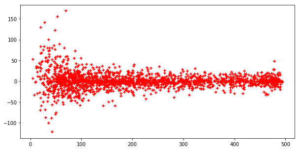

```python
t2_traj_info=pd.DataFrame()
t2_traj_info['angle'] = pd.DataFrame(t2.groupby('particle').agg(smoothened_single_traj_angle).x)
t2_traj_info['length'] = pd.DataFrame(t2.groupby('particle').agg(tp.diagonal_size).x)
plt.scatter(t2_traj_info.length,t2_traj_info.angle,marker='+',color='r')
```

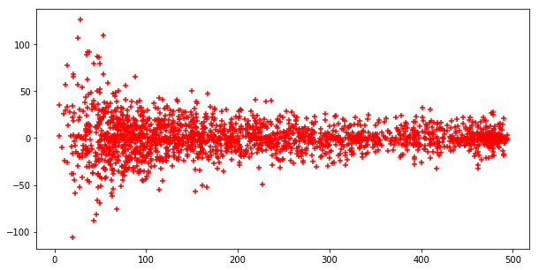

```python
t2_traj_info=pd.DataFrame()
t2_traj_info['angle'] = pd.DataFrame(t2.groupby('particle').agg(single_traj_angle).x)
t2_traj_info['length'] = pd.DataFrame(t2.groupby('particle').agg(tp.diagonal_size).x)
plt.scatter(t2_traj_info.length,t2_traj_info.angle,marker='+',color='r')
```

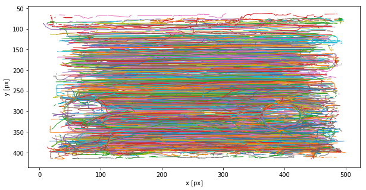

```python
tp.plot_traj(t2_smooth.groupby('particle').filter(lambda x: abs(single_traj_angle(x)) < 40 and tp.diagonal_size(x)>50))
```

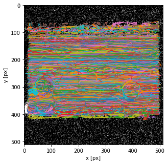

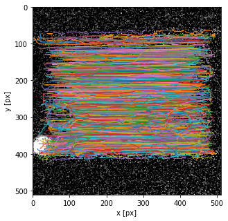

```python
tp.plot_traj(t2.groupby('particle').filter(lambda x: abs(single_traj_angle(x)) < 70 and tp.diagonal_size(x)>50),superimpose=frames[1000])
tp.plot_traj(t2_smooth.groupby('particle').filter(lambda x: abs(single_traj_angle(x)) < 70 and tp.diagonal_size(x)>50),superimpose=frames[1000])
```

## Particle Density

```python
smooth_tjs = t2_smooth.groupby('particle').filter(lambda x: abs(single_traj_angle(x)) < 70 and tp.diagonal_size(x)>50)
particle_density = pd.DataFrame(smooth_tjs[['particle','x','y']])
grouped = particle_density.groupby(['particle'])
#agg = grouped.aggregate(np.mean)
agg = grouped.aggregate(np.median)
```

```
array([[<matplotlib.axes._subplots.AxesSubplot object at 0x1cfbb762e8>,
      dtype=object)
```

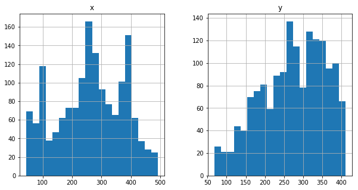

```python
agg.hist(bins=20)
```

## TP Default Plot: Mass vs Size

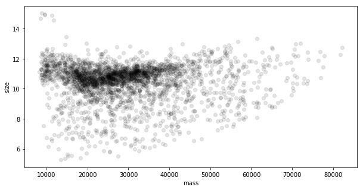

```python
plt.figure()
tp.mass_size(t2.groupby('particle').mean());
```

```python
## Plot Density Profile as a function of time
```

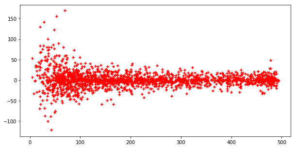

```python
t2_traj_info=pd.DataFrame()
t2_traj_info['angle'] = pd.DataFrame(t2.groupby('particle').agg(smoothened_single_traj_angle).x)
t2_traj_info['length'] = pd.DataFrame(t2.groupby('particle').agg(tp.diagonal_size).x)
plt.scatter(t2_traj_info.length,t2_traj_info.angle,marker='+',color='r')
```

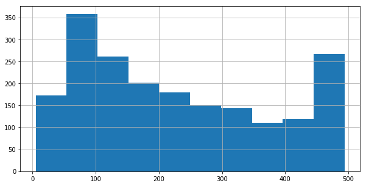

```python
t2_traj_info['length'].hist()
```

## Plotting 1000 frames each: Particle Density Distribution

```
0
1000
2000
3000
4000
5000
6000
7000
8000
9000
```

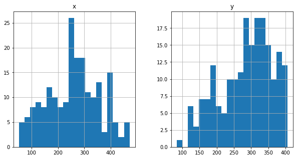

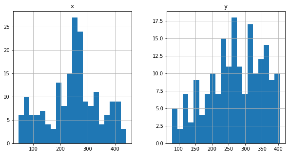

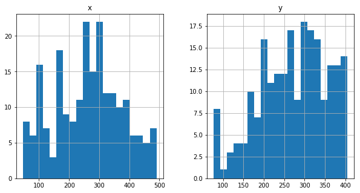

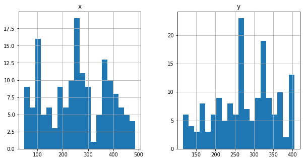

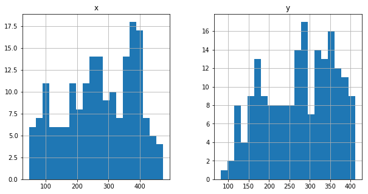

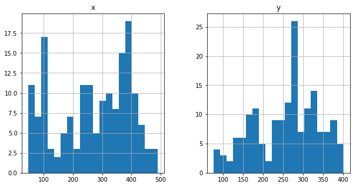

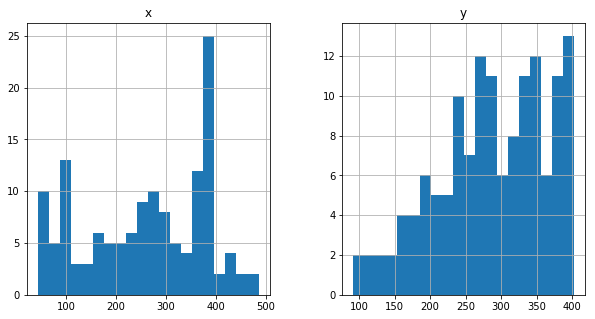

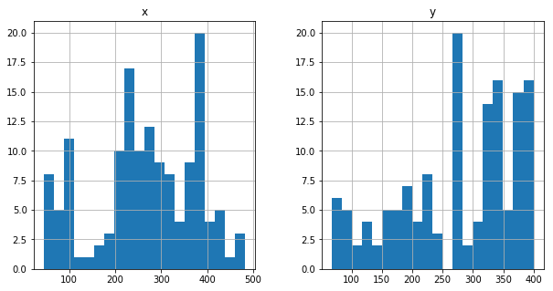

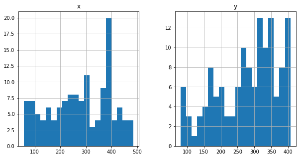

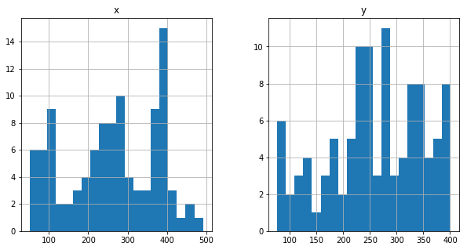

```python
for step in range(0,10000,1000):
    print(step)
    t2_1 =  t2_smooth[(t2_smooth.frame < step+1000) & (t2_smooth.frame >step)]
    smooth_tjs = t2_1.groupby('particle').filter(lambda x: abs(single_traj_angle(x)) < 70 and tp.diagonal_size(x)>50)
    particle_density = pd.DataFrame(smooth_tjs[['particle','x','y']])
    #agg = grouped.aggregate(np.mean)
    agg = particle_density.groupby(['particle']).aggregate(np.median)
    agg.hist(bins=20)
```

```python
# Just plot Velocity and Brightness as a function of x,y grid and then sum as trajectories??
```